# Chapter 5 - Logistic Regression

Stephen Roecker and Tom D’Avello

2020-03-13

# Objectives

- Introduce Generalized Linear Models (GLMs) broadly
- Examine Logistic Regression
  - Examples
  - Fitting
  - Accuracy
  - Interpret
  - Assumptions
  - Variable Selection

# Pesky ‘Linear Model’ Assumptions (review)

- *Linearity* - Y is *linearly* related to X.
- *Independence of Error* - the error (residual) is *independent* for each value of X.
- *Homoscedasticity* - the *variation* around the regression line is *constant* for all values of X.
- *Normality* - the values of Y are *normally* distributed at each value of X.

# Comparison between Linear Models and GLMs

| Type | Distributions | Estimation Method | Goodnesss of Fit |
| --- | --- | --- | --- |
| Linear | Gaussian (i.e. Normal) | least squares | variance |
| GLM | Any Exponential Family | maximum-likelihood | deviance |

# Generalized Linear Models (fewer assumptions)

| Family (or Distribution) | Default Link Function | Data Type | Example |
| --- | --- | --- | --- |
| Gaussian | identity | interval or ratio | clay content |
| Binomial | logit | binary (yes/no) or binomial (proportions) | presense of mollisols |
| Poisson | log | counts | # of species |

# Overview - Logistic Regression

- Response = binary (yes or no)(1 or 0) or binomial (0 to 1)(0 to 100%)
- Prediction = probability ( e.g. 0 - 100%)
- A threshold value, often 0.5, is used to determine if the prediction is part of the modeled class

# Example 1: Probability of Mollisols

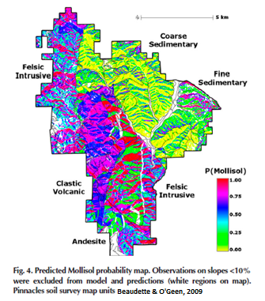

Beaudette & O’Geen, 2009

# Example 2: Probability of Red Clay

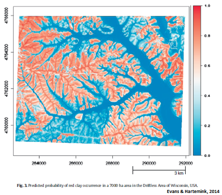

Evans & Hartemink, 2014

# Example 3: Probability of Ponding

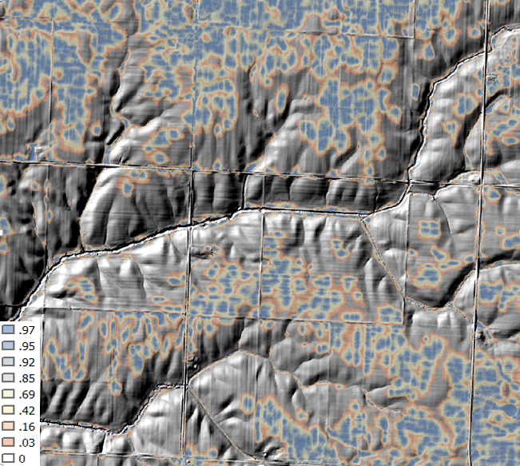

NRCS Unpublished

# Example 4: Aggregate representation of genetic soil horizons

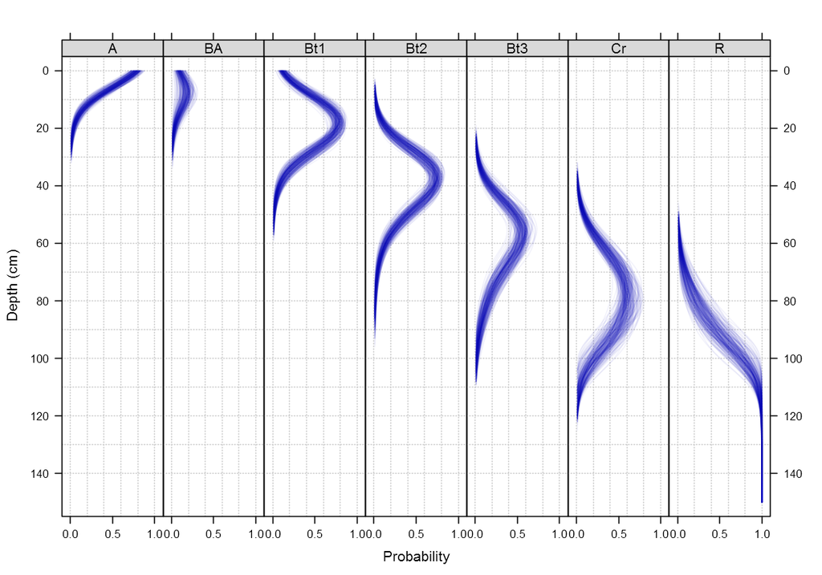

[2015 Digital Soil Morphometrics talk](http://soilmap2-1.lawr.ucdavis.edu/dylan/presentations/2015-morphometrics-ghl/presentation.html)

# Logistic Link Function

Does this look familiar?

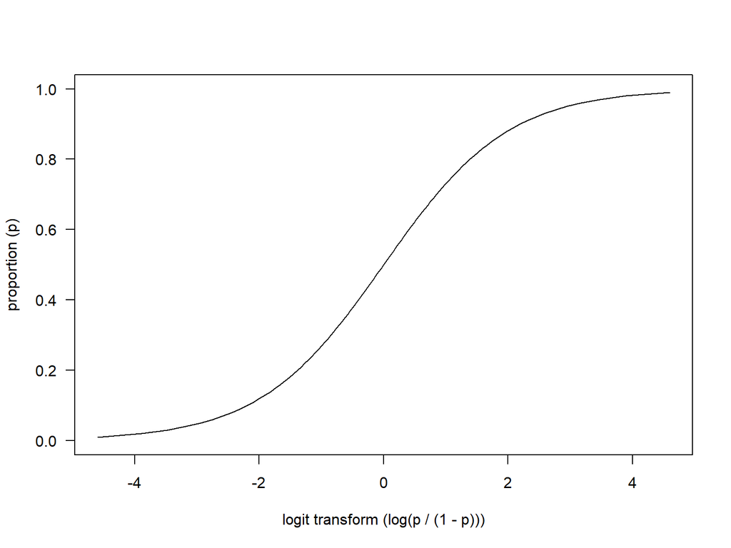

# Logistic Fit

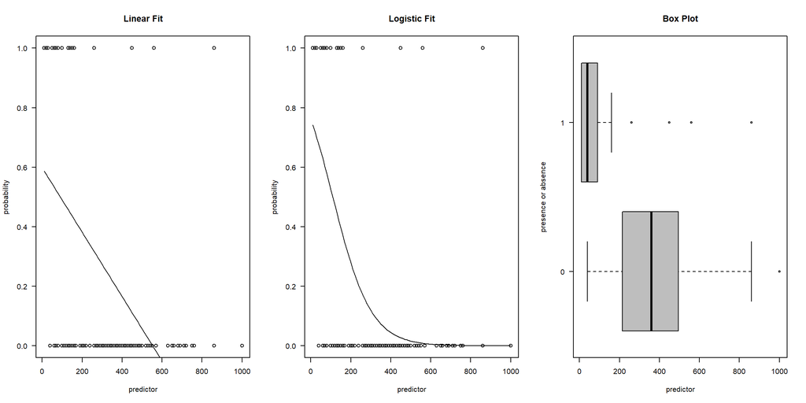

# Fitting

```r
spod.glm <- glm(spod ~ dem10m + eastness + northness + maxent, family = binomial, data = wv)
summary(spod.glm)
```

```
##
## Call:
## glm(formula = spod ~ dem10m + eastness + northness + maxent,
##     family = binomial, data = wv)
##
## Deviance Residuals:
##     Min       1Q   Median       3Q      Max
## -1.7958  -0.7920  -0.4946   0.8902   2.3825
##
## Coefficients:
##              Estimate Std. Error z value Pr(>|z|)
## (Intercept)  7.450480   2.328311   3.200 0.001375 **
## dem10m      -0.008974   0.002347  -3.823 0.000132 ***
## eastness    -0.864715   0.256272  -3.374 0.000740 ***
## northness    0.675560   0.230950   2.925 0.003443 **
## maxent       0.031468   0.008573   3.671 0.000242 ***
## ---
## Signif. codes:  0 '***' 0.001 '**' 0.01 '*' 0.05 '.' 0.1 ' ' 1
##
## (Dispersion parameter for binomial family taken to be 1)
##
##     Null deviance: 307.11  on 249  degrees of freedom
## Residual deviance: 254.47  on 245  degrees of freedom
## AIC: 264.47
##
## Number of Fisher Scoring iterations: 4
```

# Accuracy - rms R package

```r
library(rms)
spod.lrm <- lrm(spod ~ dem10m + eastness + northness + maxent, data = wv)
print(spod.lrm)
```

```
## Logistic Regression Model
##
##  lrm(formula = spod ~ dem10m + eastness + northness + maxent,
##      data = wv)
##
##                        Model Likelihood     Discrimination    Rank Discrim.
##                           Ratio Test           Indexes           Indexes
##  Obs           250    LR chi2      52.63    R2       0.268    C       0.773
##   FALSE        174    d.f.             4    g        1.339    Dxy     0.546
##   TRUE          76    Pr(> chi2) <0.0001    gr       3.817    gamma   0.546
##  max |deriv| 1e-09                          gp       0.234    tau-a   0.232
##                                             Brier    0.167
##
##            Coef    S.E.   Wald Z Pr(>|Z|)
##  Intercept  7.4505 2.3284  3.20  0.0014
##  dem10m    -0.0090 0.0023 -3.82  0.0001
##  eastness  -0.8647 0.2563 -3.37  0.0007
##  northness  0.6756 0.2310  2.93  0.0034
##  maxent     0.0315 0.0086  3.67  0.0002
##
```

# Accuracy - modEvA R package

```r
library(modEvA)
cbind(d.squared     = Dsquared(spod.glm),
      adj.d.squared = Dsquared(spod.glm, adjust = TRUE)
      )
```

```
##      d.squared adj.d.squared
## [1,] 0.1713869     0.1578586
```

```r
rbind(RsqGLM(spod.glm))
```

```
##      CoxSnell  Nagelkerke McFadden  Tjur      sqPearson
## [1,] 0.1898509 0.268436   0.1713869 0.2054845 0.209848
```

# Accuracy - Confusion Matrix

```r
library(caret)
cm <- table(observed = wv$spod, predicted = predict(spod.glm, type = "response") > 0.5)
confusionMatrix(cm, positive = "TRUE")
```

```
## Confusion Matrix and Statistics
##
##         predicted
## observed FALSE TRUE
##    FALSE   158   16
##    TRUE     38   38
##
##                Accuracy : 0.784
##                  95% CI : (0.7278, 0.8334)
##     No Information Rate : 0.784
##     P-Value [Acc > NIR] : 0.536375
##
##                   Kappa : 0.4443
##
##  Mcnemar's Test P-Value : 0.004267
##
##             Sensitivity : 0.7037
##             Specificity : 0.8061
##          Pos Pred Value : 0.5000
##          Neg Pred Value : 0.9080
##              Prevalence : 0.2160
##          Detection Rate : 0.1520
##    Detection Prevalence : 0.3040
##       Balanced Accuracy : 0.7549
##
##        'Positive' Class : TRUE
##
```

# Accuracy - Probability Threshold

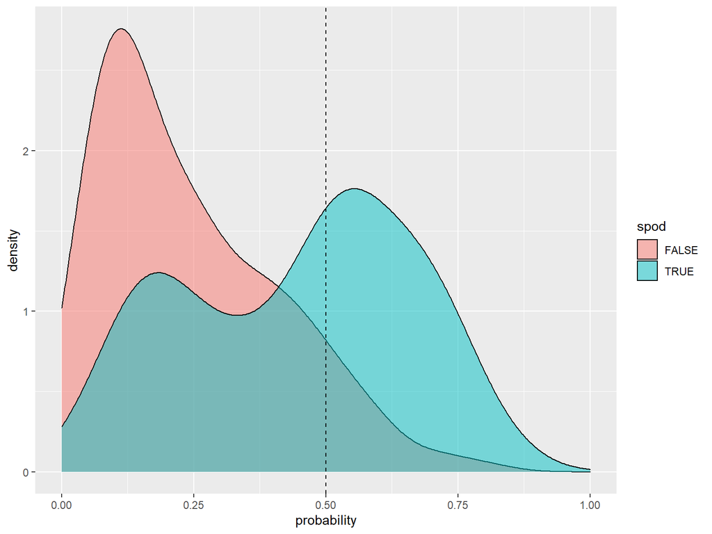

# Interpreting the Coefficients

```r
# extract coefficient, stored in log(odds)
coef(spod.glm)
```

```
##  (Intercept)       dem10m     eastness    northness       maxent
##  7.450480458 -0.008974187 -0.864714623  0.675560332  0.031468219
```

```r
# convert coefficient to odds
exp(coef(spod.glm))
```

```
##  (Intercept)       dem10m     eastness    northness       maxent
## 1720.6896668    0.9910660    0.4211717    1.9651338    1.0319686
```

# Interpreting the Coefficients - Partial Effect Plots

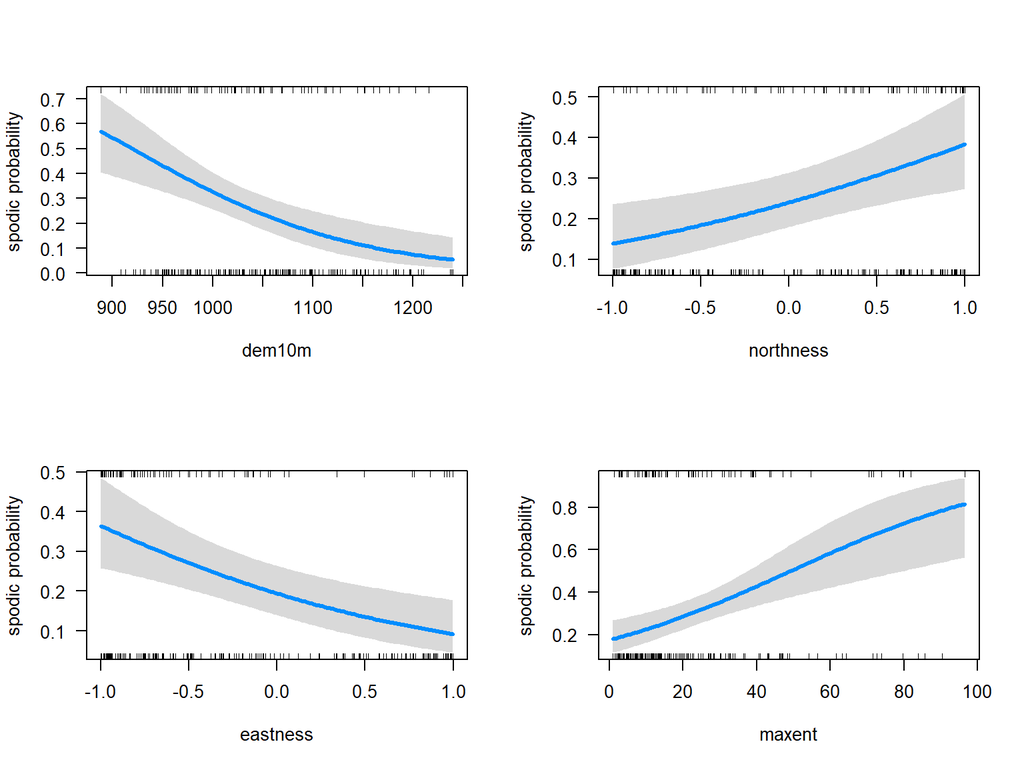

```r
library(visreg); par(mfcol = c(2, 2))
visreg(spod.glm, scale = "response", ylab = "spodic probability")
```

# Interpreting the Coeficiencts - Deviance Explained

```r
anova(spod.glm)
```

```
## Analysis of Deviance Table
##
## Model: binomial, link: logit
##
## Response: spod
##
## Terms added sequentially (first to last)
##
##
##           Df Deviance Resid. Df Resid. Dev
## NULL                        249     307.11
## dem10m     1   8.0805       248     299.03
## eastness   1  23.2714       247     275.76
## northness  1   7.0218       246     268.73
## maxent     1  14.2606       245     254.47
```

# Interpreting the Coeficiencts - Deviance Explained

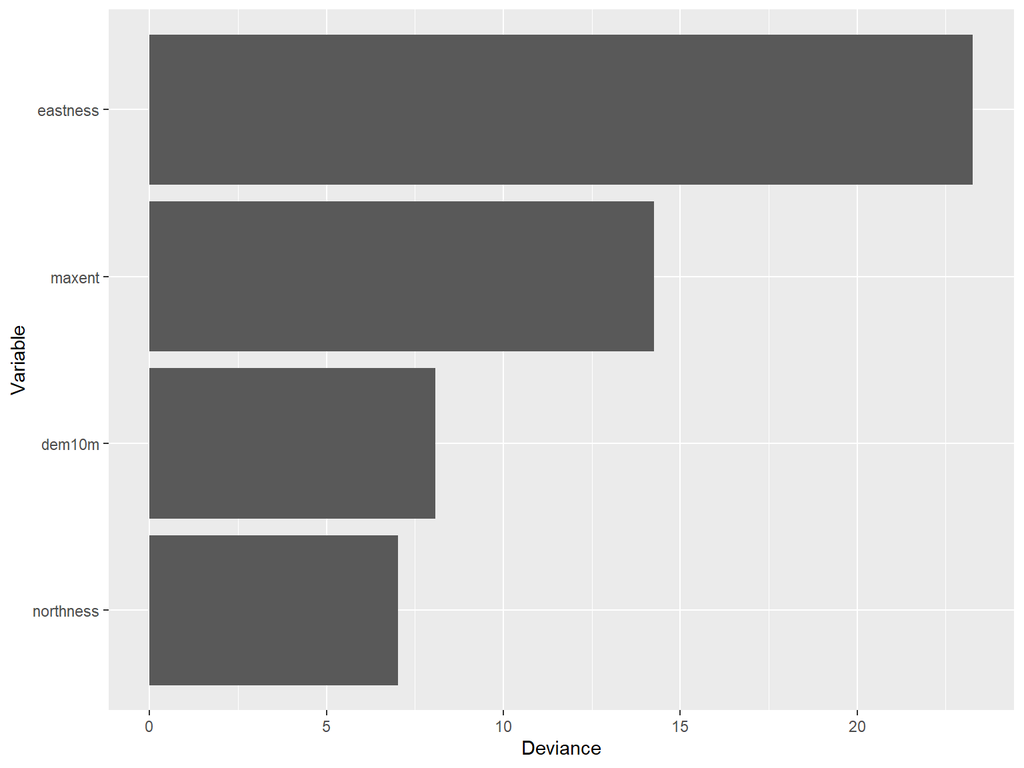

# Checking Assumptions - Multicollinearity

- Leads to unstable coefficients and large SE for coefficients
- Rules of thumb vary, but a square root of vif greater than 2 or 3 indicates an unacceptable value.

```
##    dem10m  eastness northness    maxent
##  1.196760  1.020541  1.014372  1.230978
```

# Checking Assumptions - Residual Plots

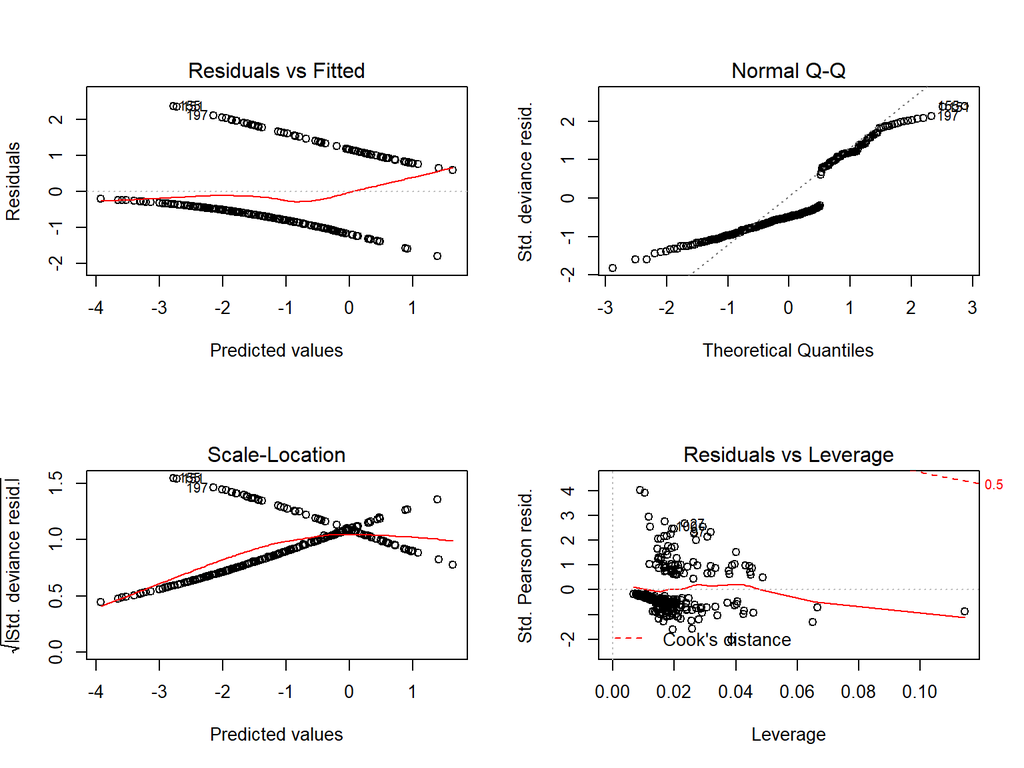

# Checking Assumptions - Resdiual Plots

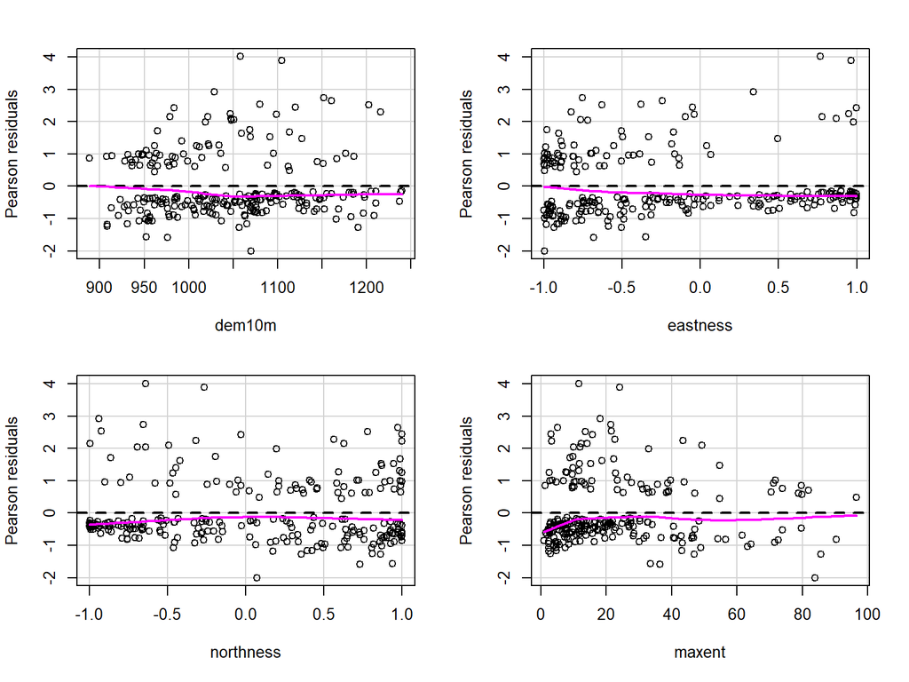

```r
library(car)
residualPlots(spod.glm, fit = FALSE, tests = FALSE)
```

# Variable Selection

```r
spod.glm2 <- glm(spod ~., data = wv)
spod.step <- step(spod.glm2, trace = FALSE)

summary(spod.step)
```

```
##
## Call:
## glm(formula = spod ~ downslpgra + eastness + mirref + ndvi +
##     northeastn + northness + planc100 + relpos11 + slp50 + solar +
##     tanc75 + pred, data = wv)
##
## Deviance Residuals:
##     Min       1Q   Median       3Q      Max
## -0.8701  -0.2469  -0.1020   0.2881   0.8774
##
## Coefficients:
##               Estimate Std. Error t value Pr(>|t|)
## (Intercept)  5.487e-01  9.936e-01   0.552  0.58129
## downslpgra  -5.105e-03  1.773e-03  -2.880  0.00434 **
## eastness     3.272e+04  2.158e+04   1.517  0.13069
## mirref      -6.202e-01  3.761e-01  -1.649  0.10047
## ndvi         1.403e+00  7.509e-01   1.869  0.06286 .
## northeastn  -4.627e+04  3.051e+04  -1.517  0.13070
## northness    3.272e+04  2.157e+04   1.517  0.13070
## planc100     3.674e-01  2.211e-01   1.662  0.09788 .
## relpos11    -3.006e-01  1.988e-01  -1.512  0.13185
## slp50       -1.179e-02  4.369e-03  -2.699  0.00745 **
## solar       -6.784e-07  4.510e-07  -1.504  0.13387
## tanc75       1.287e+00  6.877e-01   1.871  0.06253 .
## pred         9.768e-01  2.165e-01   4.512 1.01e-05 ***
## ---
## Signif. codes:  0 '***' 0.001 '**' 0.01 '*' 0.05 '.' 0.1 ' ' 1
##
## (Dispersion parameter for gaussian family taken to be 0.1611452)
##
##     Null deviance: 52.896  on 249  degrees of freedom
## Residual deviance: 38.191  on 237  degrees of freedom
## AIC: 267.76
##
## Number of Fisher Scoring iterations: 2
```

# Variable Selection

- AIC (Akaike Information Criterion) - smaller is better
- `drop1()` reports the size of the model without the variable, thus drop smaller AIC values

```r
drop1(spod.step, test = "Chisq")
```

```
## Single term deletions
##
## Model:
## spod ~ downslpgra + eastness + mirref + ndvi + northeastn + northness +
##     planc100 + relpos11 + slp50 + solar + tanc75 + pred
##            Df Deviance    AIC scaled dev.  Pr(>Chi)
## <none>          38.191 267.76
## downslpgra  1   39.528 274.36      8.5982  0.003365 **
## eastness    1   38.562 268.17      2.4146  0.120208
## mirref      1   38.630 268.61      2.8521  0.091254 .
## ndvi        1   38.754 269.42      3.6577  0.055810 .
## northeastn  1   38.562 268.17      2.4146  0.120208
## northness   1   38.562 268.17      2.4146  0.120209
## planc100    1   38.636 268.65      2.8961  0.088794 .
## relpos11    1   38.560 268.16      2.4002  0.121317
## slp50       1   39.366 273.33      7.5703  0.005934 **
## solar       1   38.556 268.13      2.3753  0.123266
## tanc75      1   38.756 269.42      3.6669  0.055502 .
## pred        1   41.472 286.36     20.6016 5.655e-06 ***
## ---
## Signif. codes:  0 '***' 0.001 '**' 0.01 '*' 0.05 '.' 0.1 ' ' 1
```

# Variable Selection - Deviance Explained

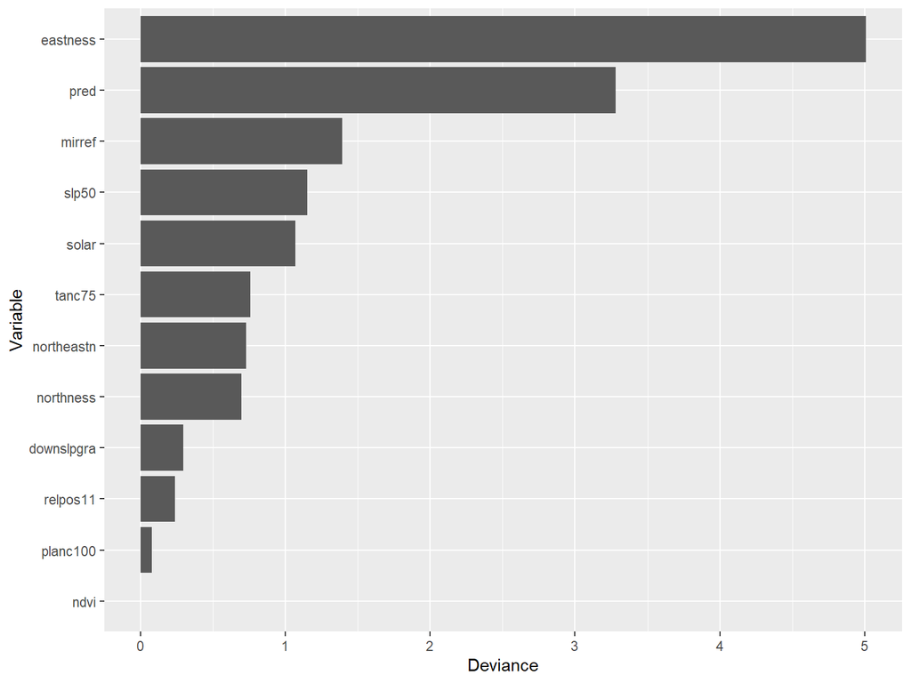

# Final Spodic Model

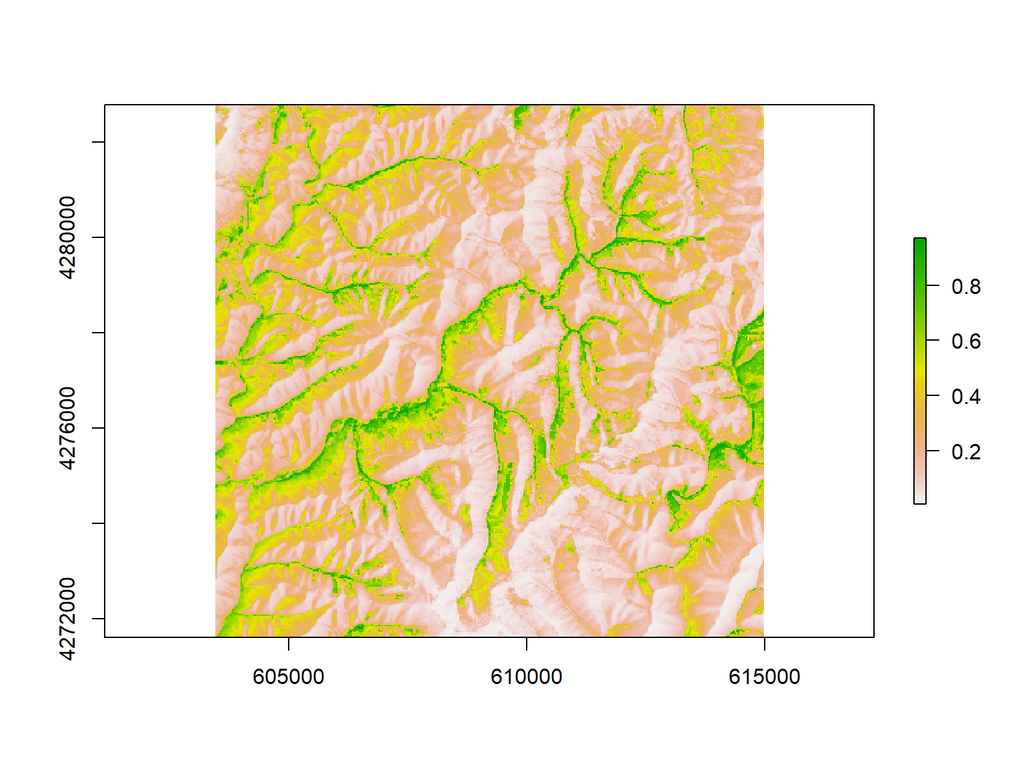

# Questions

?….

# References

Beaudette, D. E., & O’Geen, A. T, 2009. Quantifying the aspect effect: an application of solar radiation modeling for soil survey. Soil Science Society of America Journal, 73:1345-1352

Evans, D.M. and Hartemink, A.E., 2014. Digital soil mapping of a red clay subsoil covered by loess. Geoderma, 230:296-304.

# Additional reading

Lane, P.W., 2002. Generalized linear models in soil science. European Journal of Soil Science 53, 241- 251. http://onlinelibrary.wiley.com/doi/10.1046/j.1365-2389.2002.00440.x/abstract

James, G., D. Witten, T. Hastie, and R. Tibshirani, 2014. An Introduction to Statistical Learning: with Applications in R. Springer, New York. http://www-bcf.usc.edu/~gareth/ISL/

Hengl, T. 2009. A Practical Guide to Geostatistical Mapping, 2nd Edt. University of Amsterdam, www.lulu.com, 291 p. ISBN 978-90-9024981-0. http://spatial-analyst.net/book/system/files/Hengl_2009_GEOSTATe2c0w.pdf